# Module 09: Text, Categories, and Dates

Imported fine is not the same as ready to count.

Chris Chizinski

## Slide Accessibility Note

- **Images:** every figure has alt text; diagrams are HTML text with labels.
- **Speaker Notes:** These slides follow the Module 09 follow-along script and the book chapter Text, Categories, and Dates. The live coding happens in `class/week_09_follow_along.R`.

## Today

Text: split, trim, NA

->

Categories: choose, order

->

Dates: pull out a part

->

Your report: a table, a number

A short module: the last 40 minutes are your project draft.

- **No Assignment 09.** Assignment 08 due **Sun Nov 22**
- **Draft due Sun Nov 29.** Nov 23 is a project workshop

## Your Project: Where We Are

|  | When | Project step |
| --- | --- | --- |
| ☑ Done | Mon Oct 26 | Create your project repo; invite the instructor and your reviewer |
| ☑ Done | Mon Nov 2 | Data audit: import, `clean_names()`, column types, missing values |
| ☑ Done | Mon Nov 9 | First figure in `report.qmd`, with `fig-cap` and `fig-alt` |
| ☑ Done | Sun Nov 15 | **Proposal due** (rendered and pushed) |
| ▶ **This week** | Mon Nov 16 | One summary table and one inline number in `report.qmd` |
| ☐ To do | Mon Nov 23 | Project workshop: draft checklist, fresh-clone render test |
| ☐ To do | Sun Nov 29 | **Draft due:** every section started, 3 figures |
| ☐ To do | Mon Nov 30 | Peer review in class: clone, render, start the review Issue |
| ☐ To do | Wed Dec 2 | Review Issue filed on your peer’s repo |
| ☐ To do | Mon Dec 7 | Revision workshop (last class) |
| ☐ To do | Sun Dec 13 | Reply to every comment on the review Issue |
| ☐ To do | Wed Dec 16 | **Final due:** last push plus the `v1.0` tag |

## Your Project Files: Proposal vs Report

- **`proposal.qmd` is finished.** Graded on your Nov 15 push. No new work in it.
- **`report.qmd` gets all project work from now on:** last week’s figure, today’s table, the Nov 29 draft. Root of the project repo, next to `proposal.qmd`.
- Figure went into the proposal last week? **Copy** it into `report.qmd`.
- Today’s table and number: **not graded**, a step toward the draft.

**No `report.qmd`?** New file in the repo root, paste, render, push:

````markdown
---
title: "Your project title"
format: html
---

```{r}
#| label: setup
#| message: false
library(tidyverse)
library(here)
library(gt)
my_data <- read_csv(here("data", "raw", "your_file.csv"))
```

## Introduction
## Data and Methods
## Results
## Interpretation
````

Full starter: Canvas Module 09 page.

## Get Today’s Files: Pull

I added two files to your **Module 05** repo on GitHub: `class/week_09_follow_along.R` and `class/data/sf_trees.csv` (31 MB).

**GitHub Desktop**

1. Commit anything changed
2. **Fetch origin**
3. **Pull origin**

**Positron**

1. Source Control: commit anything changed
2. **…** menu > **Pull**

## Stuck On The Pull?

| You see | Do this |
| --- | --- |
| Positron: “reconcile **divergent branches**” | Terminal: `git pull --no-rebase --no-edit`, then push |
| No Pull option / “not a git repository” | Open the Module 05 repo folder |
| Anything else after 3 minutes | Download both files below into `class/` and `class/data/` |

Download the Module 09 follow-along script (.R)

[Download sf_trees.csv from TidyTuesday (31 MB)](https://raw.githubusercontent.com/rfordatascience/tidytuesday/main/data/2020/2020-01-28/sf_trees.csv)

## Setup Check

1. **Session > Restart R**
2. Open `class/week_09_follow_along.R`, run Section 0
3. `dim(trees)` **192987 12**

## Learning Goals

- **Split** a text column that holds two facts, **trim** it, and turn placeholder text into `NA`
- Make values that mean the same thing **match** (`str_to_lower()`)
- **Choose** and **order** category levels for a plot (`fct_lump_n()`, `fct_infreq()`), and say so in the caption
- Pull the **part of a date** a question needs (`year()`, `wday()`)
- Put a **`gt` table** and an **inline value** in your project report

## The Data: San Francisco Street Trees

| Column | What it holds | The decision |
| --- | --- | --- |
| `species` | `"Platanus x hispanica :: Sycamore: London Plane"` | split into two columns |
| `plot_size` | `"Width 3ft"`, `"3x3"`, `"3X3"` (525 versions) | match the spelling |
| `caretaker` | 22 groups, one with 162,000 trees | lump the small ones |
| `date` | planting date; **65% missing** | say what the dates cover |

192,987 trees, the city’s public inventory, via TidyTuesday 2020-01-28.

## The Most Common “Species”

| species | n |
| --- | --- |
| `Tree(s) ::` | 11,629 |
| `Platanus x hispanica :: Sycamore: London Plane` | 11,557 |
| `Metrosideros excelsa :: New Zealand Xmas Tree` | 8,744 |

**Is `Tree(s)` a species?** The inventory did not record one. It is text, so R counts it like any other name until you make it `NA`.

## One Column, Two Facts

```r
trees_sp <- trees |>
  separate_wider_delim(species, delim = "::",
                       names = c("scientific", "common"),
                       too_few = "align_start") |>       # rows with no "::"
  mutate(across(c(scientific, common), str_trim),        # spaces left over
         across(c(scientific, common), \(x) na_if(x, "")),
         scientific = na_if(scientific, "Tree(s)"))      # placeholder -> NA
```

**CHECK:** `no_scientific` **13468**, `no_common` **15086**

## Same Thing, Different Spelling

`plot_size` has **525** distinct values. Lowercase first:

```r
n_distinct(str_to_lower(trees$plot_size))   # 465
```

Then pull the number out of the `"width ..."` rows:

```r
width_ft = if_else(str_detect(plot_size, "^width"),
                   as.numeric(str_extract(plot_size, "[0-9.]+")), NA)
```

**CHECK:** `has_width` **85694**, `width_zero` **17017**. What does “Width 0ft” mean for a tree?

## Challenge 1 (10 min)

- **Step 1:** the five most common trees by **common name**, unknowns removed. **CHECK: London Plane 11557 first, Victorian Box 7122 fifth**
- **Step 2:** how many trees have **“Cherry”** anywhere in the common name? **CHECK: 14571**

## Challenge 1: Hint 1, The Plan

**Step 1**

1. Start from `trees_sp`
2. `filter(!is.na(common))`
3. `count(common, sort = TRUE)`
4. `head(5)`

**Step 2**

1. Start from `trees_sp`
2. `filter(str_detect(common, "Cherry"))`
3. `nrow()`
4. Why more than “Cherry Plum” alone? `str_detect()` matches **anywhere**

Still stuck? **Hint 2** is in the book: [Text, Categories, and Dates, In-Class Challenge Hints](https://nres800-fall2026.netlify.app/chapters/09-text-categories-dates.html#in-class-challenge-hints).

## 550 Names Make 550 Bars

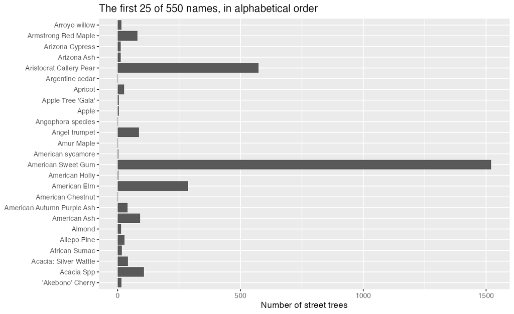

Alphabetical order answers no question.

## Choose The Levels, Then Order Them

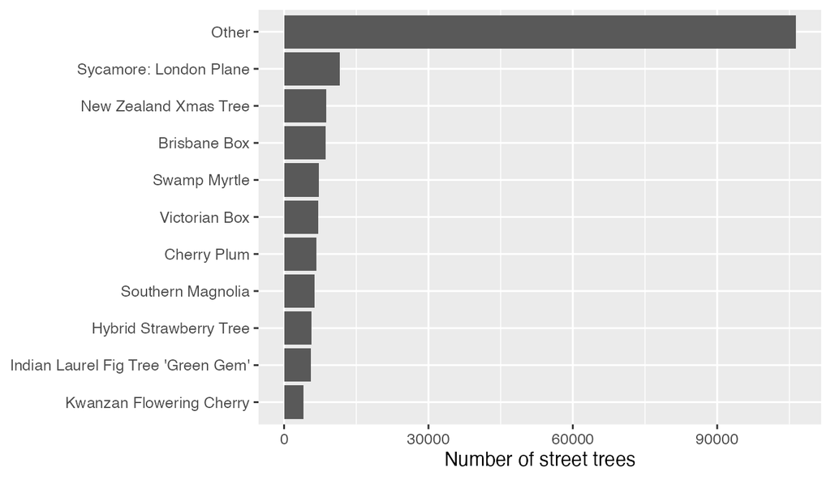

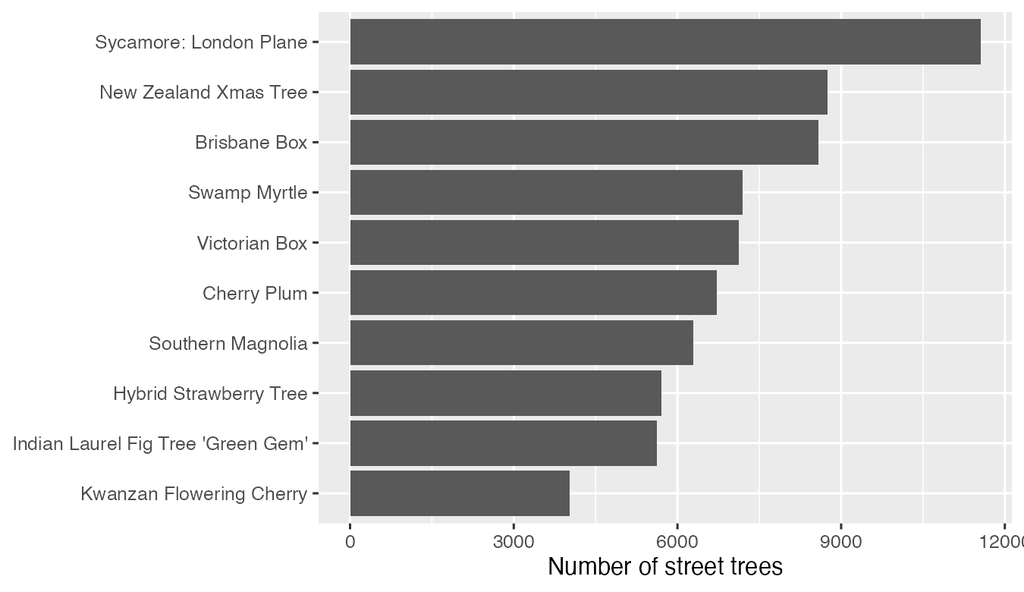

`fct_lump_n(common, n = 10)`, then `fct_rev(fct_infreq(common))`. **Other is 60%** of named trees: keep it and explain it, or drop it and say “the 10 most common”.

## Challenge 2 (10 min)

Who looks after the trees? **Lump `caretaker` to the top 3 plus Other**, bars ordered by count, biggest on top.

**CHECK:** Private, DPW, **Other**, SFUSD. Why is Other third?

## Challenge 2: Hint 1, The Plan

1. Start from `trees` (caretaker needs no cleaning)
2. `mutate(caretaker = fct_lump_n(caretaker, n = 3))`
3. `ggplot(aes(y = fct_rev(fct_infreq(caretaker)))) + geom_bar()`
4. Other is 19 small groups together, so it outranks SFUSD. To force it last: `fct_relevel(caretaker, "Other", after = Inf)` after `fct_infreq()`

## Break (10 min)

## Dates: Pull Out The Part You Need

**124,610** trees (65%) have **no** planting date.

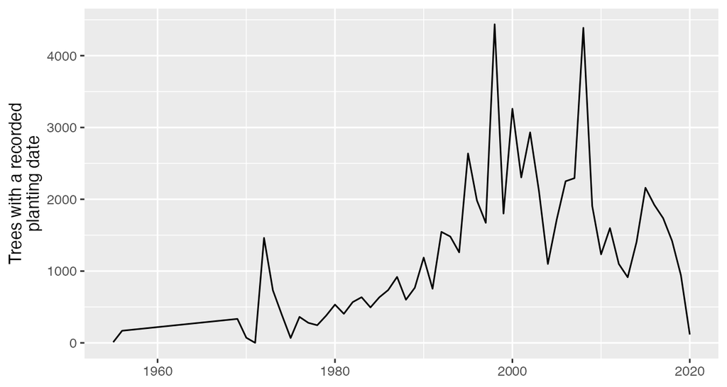

This figure describes **dated records**. Is the drop after 2016 fewer trees, or records not yet entered?

## Which Day?

```r
planted <- trees |>
  filter(!is.na(date)) |>
  mutate(year = year(date),
         weekday = wday(date, label = TRUE, week_start = 1))  # A08 again
```

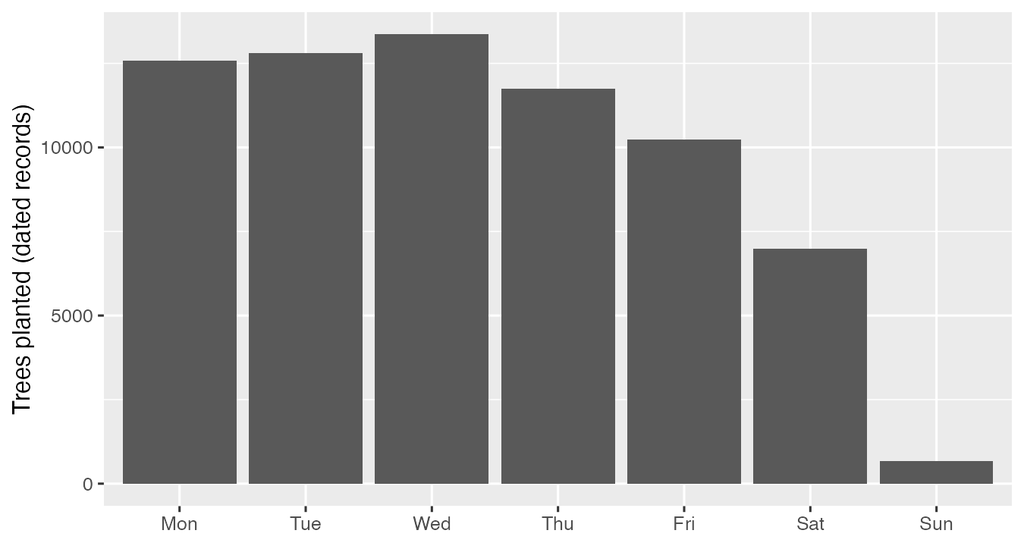

**Sat 10.2%, Sun 1.0%.** What would you check before saying so in a report?

## Your Report: One Table, One Number (20 min)

**A table** (a chunk in `report.qmd`)

```r
#| label: tbl-top-trees
#| tbl-cap: "The five most common street trees."
top5 |>
  gt() |>
  cols_label(common = "Common name",
             n = "Street trees") |>
  fmt_number(columns = n, decimals = 0)
```

**A number in a sentence** (in the text, not a chunk)

```
The city lists `r format(nrow(trees), big.mark = ",")`
street trees.
```

Renders as: The city lists 192,987 street trees.

A typed number goes stale. An inline value is recomputed every render.

`library(gt)` fails? `install.packages("gt")`.

## Draft Work Time (20 min)

- `report.qmd` renders after **Restart R**?
- **3 figures**, each with `fig-cap` and `fig-alt`?
- Every section started?

Ask me now. Nov 23 is a full workshop.

## What Is Next

- **Assignment 08** due **Sun Nov 22**, 11:59 PM
- **Mon Nov 23:** project workshop. Bring your draft and your questions
- **Draft due Sun Nov 29:** `report.qmd` renders, every section started, 3 figures

## Before You Leave

- Follow-along runs top to bottom after restarting R
- **Commit and push `class/`** in your **Module 05** repo
- One `gt` table and one inline value in your project `report.qmd`, pushed